# Genre Coherence in Spotify’s Audio Feature Space

STAT 4710/5710 — Modern Data Mining, Spring 2026

Sung Cho, Etienne Lee, Leo Li

2026-04-30

## Executive Summary

Music streaming platforms like Spotify rely on genre labels to organize and surface music to over 600 million listeners, yet it remains unclear whether these labels reflect genuine acoustic similarity or cultural and commercial convention. Using a dataset of 89,741 Spotify tracks across 113 genres, we ask a concrete empirical question: do songs within the same genre actually sound similar to each other?

We address this through six analyses spanning unsupervised clustering (PCA, UMAP, k-means, hierarchical), within-genre coherence ranking, popularity regression (OLS and lasso), random forest boundary song detection, feature importance comparison, and audio feature geometry.

The answer is consistent across all six angles: genre labels do not correspond to natural acoustic clusters. Clustering recovers almost none of the genre structure from audio features alone (ARI ≈ 0.02). Genres vary dramatically in internal coherence — from tight production-template genres like edm and party to broad cultural umbrellas like world-music and anime. Genre labels predict popularity better than audio features do, but explain little overall variance, confirming they function as market signals rather than acoustic descriptors. Boundary song detection surfaces musically interpretable crossover cases that demonstrate genre boundaries are fuzzy thresholds on a continuous acoustic space. Despite absent clusters, the audio feature space has meaningful geometric directionality along interpretable axes.

## Introduction and Motivation

Music streaming platforms like Spotify serve over 600 million listeners, relying on genre labels as one of several inputs to power recommendations, playlist curation, and music discovery. Yet genre boundaries have always been contested — artists blend styles, scenes evolve, and industry labels often reflect cultural identity or marketing logic as much as musical content. If genre labels do not genuinely reflect acoustic similarity, they become a noisy input that could systematically misdirect listeners away from music they would actually enjoy, and push independent artists into the wrong audiences. Beyond streaming, genre labels permeate music metadata, radio programming, retail categorization, and academic research in music information retrieval — making the question of their acoustic validity broadly relevant.

This project asks a concrete empirical question: do songs within the same genre actually sound similar to each other? And if not, which genres are the worst offenders, and what does the boundary between genres actually look like in practice?

Using Spotify’s 10 continuous audio features across 89,741 tracks and 113 genres, we aim to provide a large-scale empirical answer to this question — one that goes beyond anecdote or single-genre case studies. Specifically, we contribute a systematic measurement of acoustic coherence across genres, a quantitative ranking of which genre labels are most and least acoustically meaningful, and a concrete identification of songs that genuinely inhabit the acoustic boundaries between genres. Our findings consistently show that genre labels do not correspond to natural acoustic clusters — though the underlying audio feature space is geometrically structured in interpretable ways.

## Data Description

The dataset is the Spotify Tracks Dataset sourced from Kaggle (author: maharshipandya), comprising approximately 114,000 tracks across 125 fine-grained genre labels. The primary feature matrix consists of 10 continuous audio features computed by Spotify’s internal audio analysis system: danceability (rhythmic regularity and ease of dancing), energy (perceptual intensity and activity), loudness (overall decibel level), speechiness (presence of spoken words), acousticness (likelihood of being acoustic), instrumentalness (absence of vocals), liveness (presence of live audience), valence (musical positiveness), tempo (beats per minute), and duration_ms (track length in milliseconds). In addition to audio features, the dataset includes track metadata such as track name, artist, album, and a popularity score on a 0–100 scale reflecting recent streaming activity.

Preprocessing involved three steps. First, duplicate tracks were removed by track ID and rows with missing values across any of the 10 audio features were dropped, yielding a cleaned dataset of 89,741 tracks across 113 genres. Second, the 113 fine-grained genre labels were manually mapped to 11 macro-genre families — Electronic/Dance, Hip-Hop/R&B, Pop, Rock/Metal, Classical/Jazz, Folk/Country/Acoustic, Latin, World/Other, Soul/Funk/Blues, Reggae/Caribbean, and Other — using a rule-based lookup table. There is no official Spotify standard for this aggregation; the mapping reflects our own judgment calls about genre similarity and represents one reasonable grouping among many possible alternatives. Third, the feature matrix was standardized to zero mean and unit variance prior to all analyses requiring distance or scale sensitivity.

Dataset summary after preprocessing

| Statistic | Value |
| --- | --- |
| Total tracks (after dedup & NA removal) | 89741 |
| Unique fine-grained genres | 113 |
| Unique macro-genres | 11 |
| Features in primary matrix | 10 |

## Exploratory Data Analysis

### Audio Feature Distributions

We first examine the marginal distributions of `popularity` and the 10 audio features to understand the shape of the data and identify any features requiring special attention before modeling.

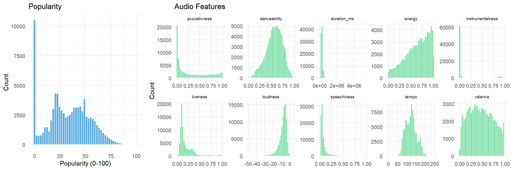

Distributions of popularity (left) and the 10 audio features (right).

`popularity` is right-skewed with a pronounced spike at 0, reflecting the large number of obscure tracks in the dataset — this will limit how much variance any model can explain. `instrumentalness` is notably bimodal, suggesting two distinct track populations (vocal vs. purely instrumental), while `speechiness` and `acousticness` are heavily right-skewed. These distributional differences reinforce the need to standardize features prior to distance-based analyses such as clustering.

### Correlation Structure

We examine the correlation structure among the 10 audio features to identify redundancies and motivate dimensionality reduction via PCA.

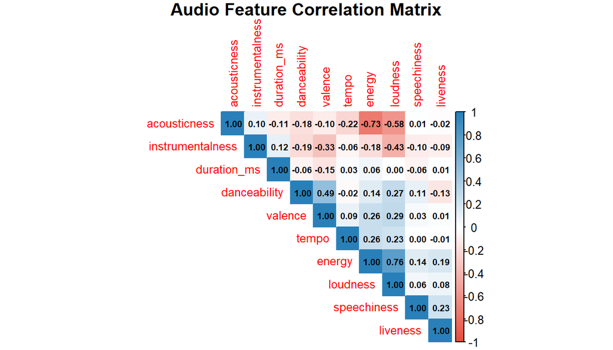

Correlation matrix of the 10 audio features.

### Popularity by Macro-Genre

We examine how popularity varies across macro-genres to establish baseline differences before modeling, and to assess whether genre carries any signal about commercial performance.

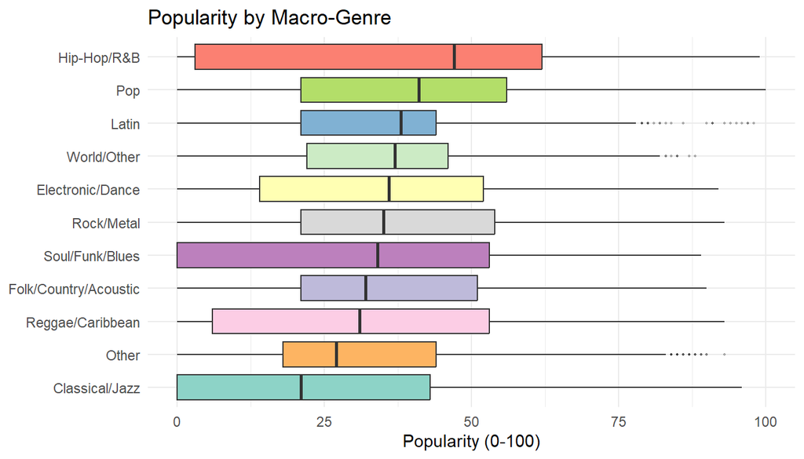

Popularity by macro-genre. Pop and Hip-Hop/R&B show the highest medians.

Hip-Hop/R&B shows the highest median popularity (~47), followed by Pop (~41), while Classical/Jazz sits lowest (~20). Notably, Pop, Hip-Hop/R&B, and Electronic/Dance all show wide interquartile ranges, reflecting the coexistence of many obscure tracks alongside breakout hits within the same genre. This variance foreshadows the difficulty of predicting popularity from genre alone.

## Results

### Angle 1: PCA and Clustering

#### PCA

We apply PCA to assess whether the 10-dimensional audio feature space can be summarized into a smaller set of components, and to provide an initial visual check of whether macro-genres occupy distinct regions of that space. PCA is appropriate here because the correlation structure in the audio features (notably energy–loudness and energy–acousticness) suggests redundant dimensions that PCA can compress.

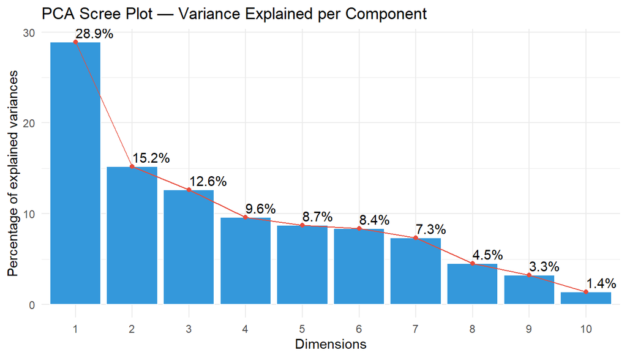

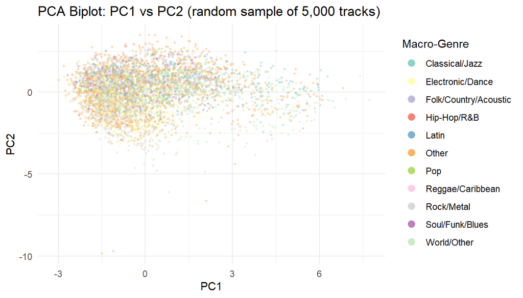

Cumulative variance explained by PCA components

| Components | Cumulative Variance Explained |
| --- | --- |
| 2 | 44% |
| 3 | 57% |
| 5 | 75% |
| 10 | 100% |

PC1 explains 28.9% of variance and PC2 15.2%; the first five components capture 75%, confirming meaningful structure in the feature space. Despite this, the biplot shows substantial genre overlap with no cleanly separated macro-genre clusters — early evidence that genre labels do not correspond to natural acoustic groupings. Classical/Jazz is the only partial exception, consistent with its distinctively high acousticness and instrumentalness.

#### UMAP Projection

Unlike PCA, UMAP preserves non-linear neighborhood structure, making it a more powerful test for genre clustering. If genres form any coherent groupings in audio space — linear or otherwise — UMAP will surface them. We use UMAP as a complement to PCA precisely because PCA’s null result could theoretically miss non-linear structure.

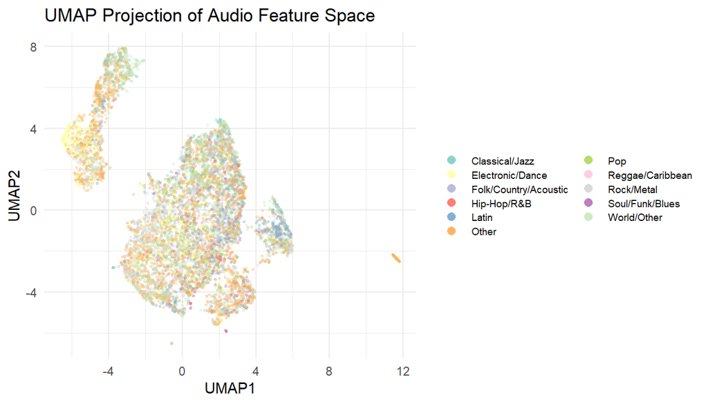

UMAP 2D projection (10,000 tracks), colored by macro-genre.

#### K-Means Clustering

We apply k-means clustering to test whether the audio feature space naturally partitions into groups that align with genre labels. The optimal number of clusters k is selected by maximizing the silhouette score, which measures how similar each point is to its own cluster relative to other clusters. To evaluate how well the resulting clusters recover genre structure, we use the Adjusted Rand Index (ARI) — a metric not covered in class that measures agreement between two labelings (here, cluster assignments vs. macro-genre labels), adjusted for chance. ARI = 1 means perfect agreement, ARI = 0 means no better than random, and negative values indicate worse than random.

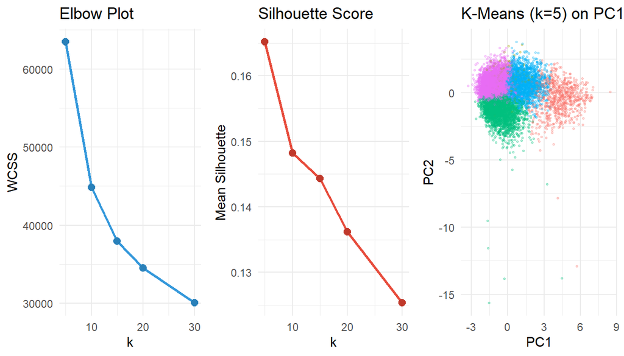

Elbow and silhouette plots (left); k-means clusters on PC1-PC2 (right).

```
## K-means ARI (k=5): 0.0168
```

The optimal k by silhouette score is k=5. The resulting ARI of 0.017 against macro-genre labels is extremely close to zero, indicating that audio-feature clusters recover almost none of the genre structure beyond chance. The elbow and silhouette plots confirm k=5 is a reasonable choice, but the cluster plot on PC1–PC2 shows clusters forming overlapping clouds with no genre-specific partitions — consistent with the PCA and UMAP results.

#### Hierarchical Clustering

To confirm the k-means result is not algorithm-dependent, we apply hierarchical clustering with Ward linkage — a deterministic, bottom-up method not covered in class that merges groups by minimizing within-cluster variance at each step.

ARI: clustering vs. macro-genre labels

| Method | k | ARI |
| --- | --- | --- |
| K-Means | 5 | 0.0168 |
| Hierarchical (Ward) | 5 | 0.0236 |

### Angle 2: Within-Genre Variance (Coherence Ranking)

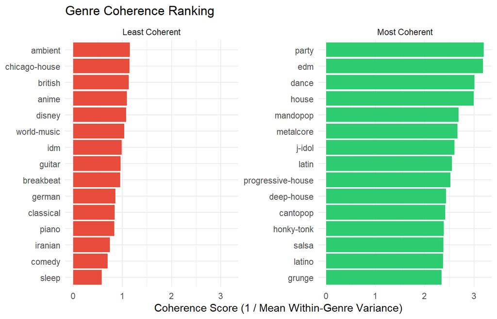

Top 15 most and least coherent fine-grained genres by coherence score (1 / mean within-genre variance).

Coherence at the macro-genre level

| macro_genre | n | mean_var | coherence_score |
| --- | --- | --- | --- |
| Reggae/Caribbean | 1195 | 0.5034 | 1.9863 |
| Pop | 5882 | 0.5502 | 1.8177 |
| Hip-Hop/R&B | 1331 | 0.5512 | 1.8143 |
| Folk/Country/Acoustic | 4312 | 0.6203 | 1.6120 |
| Rock/Metal | 10528 | 0.6319 | 1.5825 |
| Soul/Funk/Blues | 3714 | 0.6620 | 1.5106 |
| Latin | 5902 | 0.6897 | 1.4500 |
| Electronic/Dance | 10144 | 0.7643 | 1.3084 |
| Classical/Jazz | 3037 | 1.0866 | 0.9203 |
| World/Other | 18175 | 1.1366 | 0.8798 |
| Other | 25521 | 1.1458 | 0.8727 |

### Angle 3: Popularity Regression

To assess whether genre labels carry commercial information beyond raw audio features, we regress popularity on the 10 standardized audio features and macro-genre dummy variables using two complementary approaches. A global OLS establishes baseline predictive power and identifies the strongest predictors. Lasso regression with cross-validated penalty selection then confirms which predictors survive regularization, guarding against overfitting.

#### OLS (Global)

```
## Adjusted R2: 0.0427
```

OLS coefficients (top 15 by |t-value|)

| term | estimate | se | t_val | p_val |
| --- | --- | --- | --- | --- |
| (Intercept) | 25.933 | 0.388 | 66.846 | 0 |
| instrumentalness | -2.664 | 0.084 | -31.581 | 0 |
| macro_genreRock/Metal | 10.476 | 0.449 | 23.329 | 0 |
| valence | -2.002 | 0.087 | -23.084 | 0 |
| macro_genrePop | 10.323 | 0.473 | 21.826 | 0 |
| danceability | 1.890 | 0.088 | 21.538 | 0 |
| macro_genreWorld/Other | 8.340 | 0.409 | 20.413 | 0 |
| macro_genreHip-Hop/R&B | 13.746 | 0.685 | 20.080 | 0 |
| macro_genreElectronic/Dance | 8.060 | 0.460 | 17.519 | 0 |
| speechiness | -1.278 | 0.074 | -17.374 | 0 |
| macro_genreOther | 5.538 | 0.409 | 13.547 | 0 |
| macro_genreLatin | 6.056 | 0.474 | 12.790 | 0 |
| macro_genreSoul/Funk/Blues | 5.890 | 0.515 | 11.428 | 0 |
| macro_genreFolk/Country/Acoustic | 5.409 | 0.490 | 11.036 | 0 |
| macro_genreReggae/Caribbean | 5.893 | 0.716 | 8.232 | 0 |

The global model achieves adjusted R² = 0.0427, confirming that audio features and genre labels together explain only ~4% of popularity variance — unsurprising given omitted factors such as artist reputation and playlist placement. The strongest predictors are instrumentalness (~-2.66), valence (~-2.00), and danceability (~1.89); macro-genre dummies (Hip-Hop/R&B ~13.75, Rock/Metal ~10.48, Pop ~10.32) are among the highest-magnitude terms, indicating genre carries information beyond raw audio features.

#### Lasso Regression

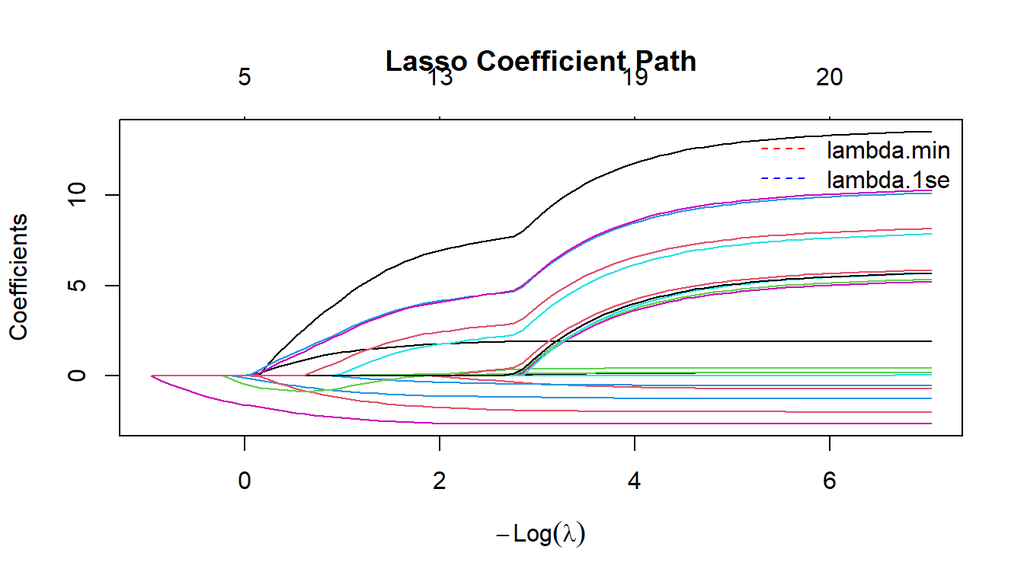

Lasso coefficient path. Dashed lines: lambda.min (red) and lambda.1se (blue).

Non-zero lasso coefficients at lambda.1se

| feature | coefficient |
| --- | --- |
| macro_genreHip-Hop/R&B | 6.5205 |
| macro_genrePop | 3.9090 |
| macro_genreRock/Metal | 3.8299 |
| instrumentalness | -2.5855 |
| macro_genreWorld/Other | 2.2107 |
| danceability | 1.6889 |
| valence | -1.6632 |
| macro_genreElectronic/Dance | 1.5132 |
| speechiness | -1.0831 |
| duration_ms | -0.2989 |
| loudness | 0.0729 |
| macro_genreOther | -0.0273 |

### Angle 4: Boundary Song Detection

Having established that genre labels lack acoustic coherence, we now ask: can we identify which specific songs are most acoustically ambiguous? We train a random forest classifier to predict macro-genre from the 10 audio features, then use its per-track class probabilities to surface boundary songs — tracks the model is most confused about. A low maximum predicted probability combined with a wrong prediction indicates a track that genuinely sits acoustically between genres. Random forest is appropriate here because it handles multi-class classification naturally, provides calibrated probability estimates, and captures non-linear feature interactions that a linear classifier would miss.

#### Random Forest Classifier

```
## Overall Accuracy: 0.5352  |  Macro F1: 0.4845
```

Per-class precision, recall, and F1 on test set

| Class | Precision | Recall | F1 |
| --- | --- | --- | --- |
| Class: Classical/Jazz | 0.7526 | 0.4712 | 0.5795 |
| Class: Electronic/Dance | 0.6516 | 0.6124 | 0.6314 |
| Class: Folk/Country/Acoustic | 0.6130 | 0.3271 | 0.4266 |
| Class: Hip-Hop/R&B | 0.9577 | 0.2556 | 0.4036 |
| Class: Latin | 0.6121 | 0.5415 | 0.5746 |
| Class: Other | 0.5014 | 0.6738 | 0.5749 |
| Class: Pop | 0.5719 | 0.3078 | 0.4002 |
| Class: Reggae/Caribbean | 0.7931 | 0.1925 | 0.3098 |
| Class: Rock/Metal | 0.5642 | 0.5905 | 0.5771 |
| Class: Soul/Funk/Blues | 0.8878 | 0.2453 | 0.3844 |
| Class: World/Other | 0.4398 | 0.4990 | 0.4675 |

#### Boundary Songs

Top 20 boundary songs: misclassified with low confidence

| track_name | artists | true_genre | pred_genre | max_prob |
| --- | --- | --- | --- | --- |
| Have You Ever Loved A Woman? | Derek & The Dominos | Soul/Funk/Blues | Pop | 0.1600 |
| It’s Been Too Long | The Whispers | Soul/Funk/Blues | World/Other | 0.1600 |
| Firefly | When Chai Met Toast | Folk/Country/Acoustic | World/Other | 0.1600 |
| Flurry Rush | Days N Daze | Folk/Country/Acoustic | Other | 0.1633 |
| Coisa, No. 1 | Baden Powell;Jimmy Pratt | Other | Latin | 0.1667 |
| SUPERMODEL | Måneskin | Other | Electronic/Dance | 0.1667 |
| Riders on the Storm | The Doors | Rock/Metal | World/Other | 0.1667 |
| Copperbelly | Red Hot Chili Peppers | Rock/Metal | Pop | 0.1700 |
| Angel Baby | Troye Sivan | Pop | World/Other | 0.1700 |
| T.K.O. | Womack & Womack | Soul/Funk/Blues | Other | 0.1700 |
| Chuck Berry Holiday | Nobunny | Electronic/Dance | Other | 0.1700 |
| Leva | Tim Maia | Latin | World/Other | 0.1700 |
| Czarna Inez | Raz Dwa Trzy | Soul/Funk/Blues | Other | 0.1733 |
| No Meio de uma Sessão | ConeCrewDiretoria | World/Other | Other | 0.1733 |
| Stay Young | Mike Perry;Tessa | Electronic/Dance | Folk/Country/Acoustic | 0.1733 |
| lil jeep | Lil Peep | Rock/Metal | Other | 0.1733 |
| Letter Y Song | Have Fun Teaching | Other | Soul/Funk/Blues | 0.1733 |
| Não Deixo Não / Incidental: Vá Pro Inferno Com Seu Amor - Ao Vivo | Edson & Hudson | Latin | Rock/Metal | 0.1733 |
| Oğluma | Cem Karaca | Rock/Metal | Other | 0.1733 |
| Cold (feat. Sia) | Leslie Odom Jr.;Sia | World/Other | Rock/Metal | 0.1733 |

### Angle 5: Feature Importance

Having used random forest for genre classification and lasso for popularity regression, we can directly compare which audio features each task relies on most. RF Gini importance measures how much each feature reduces impurity across all trees — higher values mean the feature is more useful for distinguishing genres. Lasso coefficients measure each feature’s contribution to predicting popularity after regularization. Comparing the two rankings reveals whether the same audio dimensions drive both genre distinctiveness and commercial success.

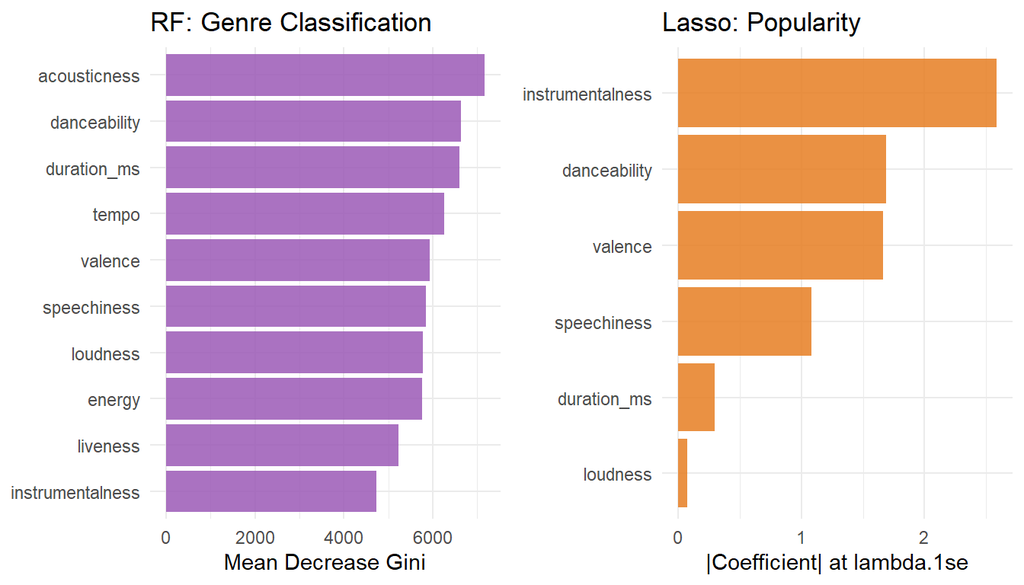

RF Gini importance (left) vs. lasso |coefficient| (right). Divergent rankings suggest genre-distinctiveness and popularity are driven by different audio dimensions.

### Angle 6: Audio Feature Geometry — A Word Embedding Analogy

Angles 1–5 establish that genre labels do not form clean clusters. This angle asks: does the audio feature space still possess meaningful geometric directionality, analogous to word2vec — the finding in NLP that vector arithmetic on word embeddings yields semantically meaningful results (e.g. king - man + woman = queen)? We define three axes from pairs of maximally distinct genre centroids and project all genres onto them.

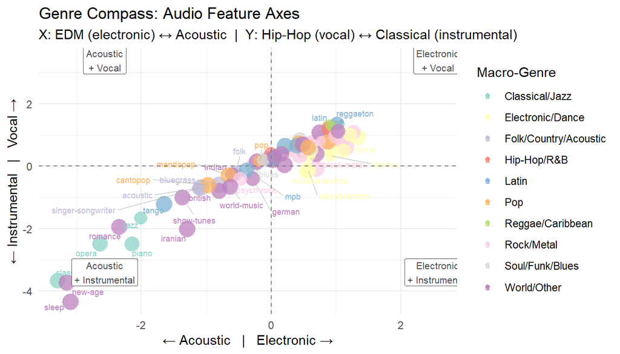

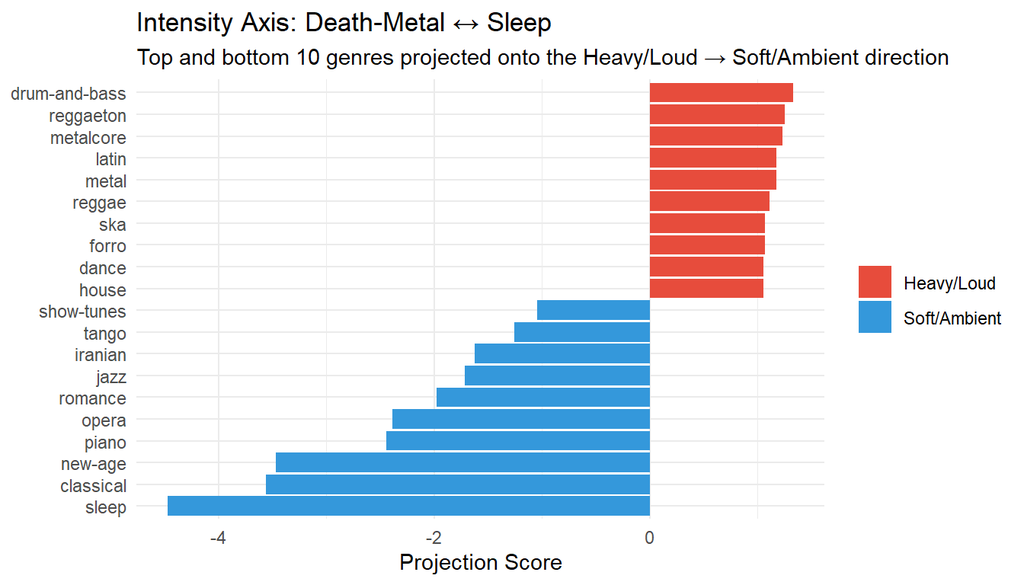

## Discussion and Conclusion

Six complementary analyses consistently answer the central question: Spotify’s genre labels do not reflect genuine acoustic coherence, but the underlying audio feature space is not structureless — it is geometrically organized along interpretable dimensions.

The popularity regression (Angle 3) reveals an important asymmetry: genre labels predict popularity better than audio features do, despite explaining little overall variance (adjusted R² = 0.043). Genre functions as a market signal — Hip-Hop/R&B and Pop carry large positive coefficients even after lasso regularization — while audio features themselves contribute relatively little.

**Limitations.** Several limitations should temper these conclusions. The dataset is a single snapshot and platform-assigned labels may reflect editorial decisions rather than community consensus. The 10-feature audio space omits melody, harmony, lyrics, rhythm complexity, and production texture — dimensions that human listeners use heavily when perceiving genre. The macro-genre mapping is one of many possible aggregations and different choices would likely shift some coherence rankings. Finally, popularity scores reflect a single point in time and do not capture long-term commercial trajectory.

## Statement on AI Use

This project used Claude Code (Anthropic, claude-sonnet-4-6) as an AI assistant throughout. All R code was written with AI assistance and reviewed by the authors; debugging of compatibility issues (Unicode, `sort` argument, `reorder()` factor handling) was done iteratively. The UMAP projection, coherence-vs-popularity analysis, and genre compass (Angle 6) were proposed by the AI; the core research question, dataset selection, and macro-genre mapping were human-defined. Section narratives and the Discussion were AI-drafted from actual outputs and reviewed by the authors. No AI tools were used to generate or fabricate data or numerical outputs.